# Time Series Models

## Alternative approach to establishing if series are autocorrelated

An alternative way to determing whether the series are autocorrelated is to compare two linear regression equations: one in which change in life expectancy is regressed against an intercept; another in which the change in life expectancy is additionally regressed against the change in the previous year

```r
alt_approach_autocorrelated <-
  hmd_ex_selected_countries_with_synth %>%
      filter(year >= 1979) %>%
      filter(!(code %in% c("DEUTE", "DEUTW", "DEUTNP"))) %>%  # Using only synthetic germany for longer time period
      group_by(code, x, sex) %>%
      arrange(year) %>%
      mutate(delta_ex = ex - lag(ex)) %>%
      nest() %>%
      mutate(
        rwd_model = map(data, ~lm(delta_ex ~ 1, data = . )),
        ar_model  = map(data, ~lm(delta_ex ~ lag(delta_ex), data = .))
      ) %>%
      mutate(
        bic_rwd = map_dbl(rwd_model, BIC),
        bic_ar  = map_dbl(ar_model, BIC)
      ) %>%
      mutate(
        diff_bic = bic_ar - bic_rwd
      ) %>%
    mutate(
      which_preferred = ifelse(diff_bic < 0, "Autocorrelated", "RWD")
    ) %>%
      left_join(country_code_lookup) %>%
      mutate(country = factor(country, levels = c("England & Wales", "Scotland", "Synthetic Germany", "Spain", "France", "Italy", "Netherlands"))) %>%
    filter(!is.na(country))
alt_approach_autocorrelated %>%
  select(country, x, sex, bic_rwd, bic_ar, which_preferred)
```

```
## # A tibble: 28 × 7
## # Groups:   code, x, sex [28]
##    code    country             x sex    bic_rwd bic_ar which_preferred
##    <chr>   <fct>           <dbl> <chr>    <dbl>  <dbl> <chr>
##  1 ESP     Spain               0 female    1.99  -7.45 Autocorrelated
##  2 ESP     Spain              65 female   -5.81 -15.4  Autocorrelated
##  3 FRATNP  France              0 female   -2.08  -4.67 Autocorrelated
##  4 FRATNP  France             65 female   -4.73 -10.4  Autocorrelated
##  5 ITA     Italy               0 female   13.4    2.80 Autocorrelated
##  6 ITA     Italy              65 female    6.71  -7.93 Autocorrelated
##  7 NLD     Netherlands         0 female  -15.4  -11.8  RWD
##  8 NLD     Netherlands        65 female  -33.1  -29.5  RWD
##  9 GBRTENW England & Wales     0 female   -8.97 -12.8  Autocorrelated
## 10 GBRTENW England & Wales    65 female  -13.9  -18.8  Autocorrelated
## # … with 18 more rows
```

This approach also identifies most, but not all, of the populations to exhibit some degree of autocorrelation. (n.b. the more stringent BIC was used instead of AICc in this example, which may explain discrepancies between approaches)

For each of the above, the intercept (average improvement per year) and autocorrelation term can be extracted as follows:

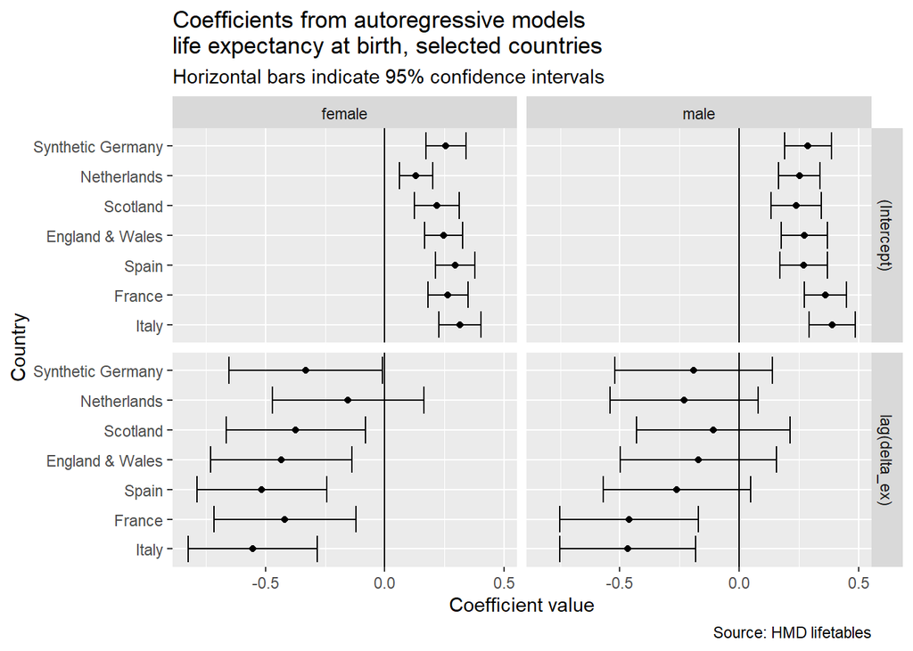

```r
alt_approach_autocorrelated  %>%
  left_join(country_code_lookup) %>%
  mutate(country = factor(country, levels = c("England & Wales", "Scotland", "Synthetic Germany", "Spain", "France", "Italy", "Netherlands"))) %>%
  filter(!is.na(country)) %>%
  select(country, x, sex, ar_model) %>%
  mutate(tidied_model = map(ar_model, broom::tidy)) %>%
  select(-ar_model) %>%
  filter(x == 0) %>%
  unnest(tidied_model) %>%
  ggplot(aes(estimate, reorder(country, estimate))) +
  geom_point() +
  facet_grid(term~sex) +
  geom_vline(xintercept = 0) +
  geom_errorbarh(aes(xmin = estimate - 1.96  * std.error, xmax = estimate + 1.96 * std.error))  +
  labs(
    x = "Coefficient value",
    y = "Country",
    title = "Coefficients from autoregressive models\nlife expectancy at birth, selected countries",
    subtitle = "Horizontal bars indicate 95% confidence intervals",
    caption = "Source: HMD lifetables"

  )
```

Here all autoregression coefficients are negative, most of which are statistically significant at p < 0.05.

The following shows the equivalent trends for x = 65

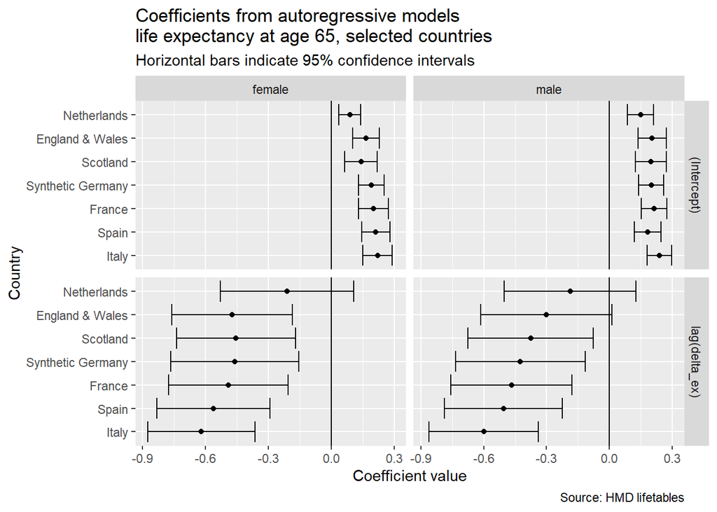

```r
alt_approach_autocorrelated  %>%
  left_join(country_code_lookup) %>%
  mutate(country = factor(country, levels = c("England & Wales", "Scotland", "Synthetic Germany", "Spain", "France", "Italy", "Netherlands"))) %>%
  filter(!is.na(country)) %>%
  select(country, x, sex, ar_model) %>%
  mutate(tidied_model = map(ar_model, broom::tidy)) %>%
  select(-ar_model) %>%
  filter(x == 65) %>%
  unnest(tidied_model) %>%
  ggplot(aes(estimate, reorder(country, estimate))) +
  geom_point() +
  facet_grid(term~sex) +
  geom_vline(xintercept = 0) +
  geom_errorbarh(aes(xmin = estimate - 1.96  * std.error, xmax = estimate + 1.96 * std.error))  +
  labs(
    x = "Coefficient value",
    y = "Country",
    title = "Coefficients from autoregressive models\nlife expectancy at age 65, selected countries",
    subtitle = "Horizontal bars indicate 95% confidence intervals",
    caption = "Source: HMD lifetables"

  )
```

Here the negative correlations appear even stronger, and of larger magnitude in Italy than elsewhere. It also appears that the two coefficients are negatively associated, with Netherlands having the lowest average annual improvement, but also the smallest (and non-significant) magnitude of negative autocorrelation; Italy appears the converse.

## Comparing a wider range of ARIMA models

The `auto.arima` function in the `fable` package allows a larger range of ARIMA-type models to be compared. The following code applies this function to each of the populations.

```r
tmp <-
series_of_interest %>%
  as_tsibble(key = c(sex, x, country), index = year) %>%
  model(arima = ARIMA(ex ~ pdq(0:3, 1, 0:3))) %>%
  report() %>%
  select(sex, x, country, ar_roots, ma_roots ) %>%
  arrange(country, x, sex)
tmp
```

```
## # A tibble: 28 × 5
##    sex        x country           ar_roots  ma_roots
##    <chr>  <dbl> <fct>             <list>    <list>
##  1 female     0 England & Wales   <cpl [1]> <cpl [0]>
##  2 male       0 England & Wales   <cpl [0]> <cpl [0]>
##  3 female    65 England & Wales   <cpl [1]> <cpl [0]>
##  4 male      65 England & Wales   <cpl [1]> <cpl [0]>
##  5 female     0 Scotland          <cpl [0]> <cpl [1]>
##  6 male       0 Scotland          <cpl [0]> <cpl [0]>
##  7 female    65 Scotland          <cpl [2]> <cpl [2]>
##  8 male      65 Scotland          <cpl [0]> <cpl [2]>
##  9 female     0 Synthetic Germany <cpl [1]> <cpl [0]>
## 10 male       0 Synthetic Germany <cpl [0]> <cpl [0]>
## # … with 18 more rows
```

The length of the vectors ar_roots and ma_roots indicate, respectively, how many ar or ma terms were identified in the best fitting model for the population indicated by sex, x (starting age) and country. For example, for females in England & Wales, from age 0, an ARIMA(1,1,0) model is preferred, whereas for females in Scotland, from age 0, an ARIMA(0, 1, 1) model is preferred.

There are few populations for which the random-walk-with-drift (RWD) model is preferred to more complex models, but also not a single alternative model specification (such as ARIMA(1,1,0)) which is preferred for the majority of populations.